# TPG Tugas Akhir

Ibrahim Zaidan

2025-12-16

# Buat Data

```r
set.seed(123)

Transport <- sample(c("Motor","Mobil","Umum","Jalan"), 120, replace = TRUE)
Puas <- sample(c("Rendah","Sedang","Tinggi"), 120, replace = TRUE)

dataCA <- table(Transport, Puas)
dataCA
```

```
##          Puas
## Transport Rendah Sedang Tinggi
##     Jalan      7      8      8
##     Mobil     14     12      6
##     Motor      9     11     12
##     Umum       8     11     14
```

Distribusi tingkat kepuasan pada setiap jenis transportasi relatif merata tanpa perbedaan mencolok.

# Uji Chi-Square

```r
chisq.test(dataCA)
```

```
##
##  Pearson's Chi-squared test
##
## data:  dataCA
## X-squared = 5.3158, df = 6, p-value = 0.504
```

Uji Chi-Square menunjukkan tidak terdapat hubungan signifikan antara jenis transportasi dan tingkat kepuasan mahasiswa.

# Analisis Korespondensi

```r
library(FactoMineR)
library(factoextra)
```

```r
modelCA <- CA(dataCA, graph = FALSE)
modelCA
```

```
## **Results of the Correspondence Analysis (CA)**
## The row variable has  4  categories; the column variable has 3 categories
## The chi square of independence between the two variables is equal to 5.31584 (p-value =  0.5039881 ).
## *The results are available in the following objects:
##
##    name              description
## 1  "$eig"            "eigenvalues"
## 2  "$col"            "results for the columns"
## 3  "$col$coord"      "coord. for the columns"
## 4  "$col$cos2"       "cos2 for the columns"
## 5  "$col$contrib"    "contributions of the columns"
## 6  "$row"            "results for the rows"
## 7  "$row$coord"      "coord. for the rows"
## 8  "$row$cos2"       "cos2 for the rows"
## 9  "$row$contrib"    "contributions of the rows"
## 10 "$call"           "summary called parameters"
## 11 "$call$marge.col" "weights of the columns"
## 12 "$call$marge.row" "weights of the rows"
```

Analisis Korespondensi dilakukan meskipun hubungan antar variabel lemah untuk melihat pola kedekatan secara visual.

# Eigen Value & Scree Plot

```r
eig <- get_eigenvalue(modelCA)
eig
```

```
##         eigenvalue variance.percent cumulative.variance.percent
## Dim.1 4.429598e-02       99.9939196                    99.99392
## Dim.2 2.693536e-06        0.0060804                   100.00000
```

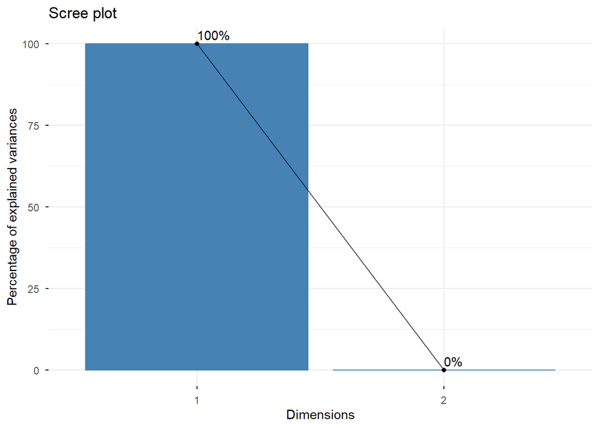

```r
fviz_screeplot(modelCA, addlabels = TRUE)
```

Dimensi pertama menjelaskan hampir seluruh variasi data, sedangkan dimensi kedua tidak memberikan informasi tambahan yang berarti.

# Koordinat dan Kontribusi

```r
row <- get_ca_row(modelCA)
row$coord
```

```
##             Dim 1         Dim 2
## Jalan -0.03350007 -0.0007681848
## Mobil  0.33420780  0.0006300181
## Motor -0.09631271 -0.0022085313
## Umum  -0.20733762  0.0020660810
```

```r
row$contrib
```

```
##            Dim 1     Dim 2
## Jalan  0.4855945  4.199090
## Mobil 67.2415384  3.929633
## Motor  5.5843373 48.289537
## Umum  26.6885298 43.581741
```

```r
col <- get_ca_col(modelCA)
col$coord
```

```
##             Dim 1         Dim 2
## Rendah  0.2399303  0.0015204861
## Sedang  0.0455157 -0.0022082363
## Tinggi -0.2757253  0.0008741863
```

```r
col$contrib
```

```
##            Dim 1    Dim 2
## Rendah 41.153648 27.17969
## Sedang  1.636915 63.36308
## Tinggi 57.209437  9.45723
```

Kategori Mobil serta kepuasan Rendah dan Tinggi memberikan kontribusi terbesar pada pembentukan dimensi utama.

# Biplot

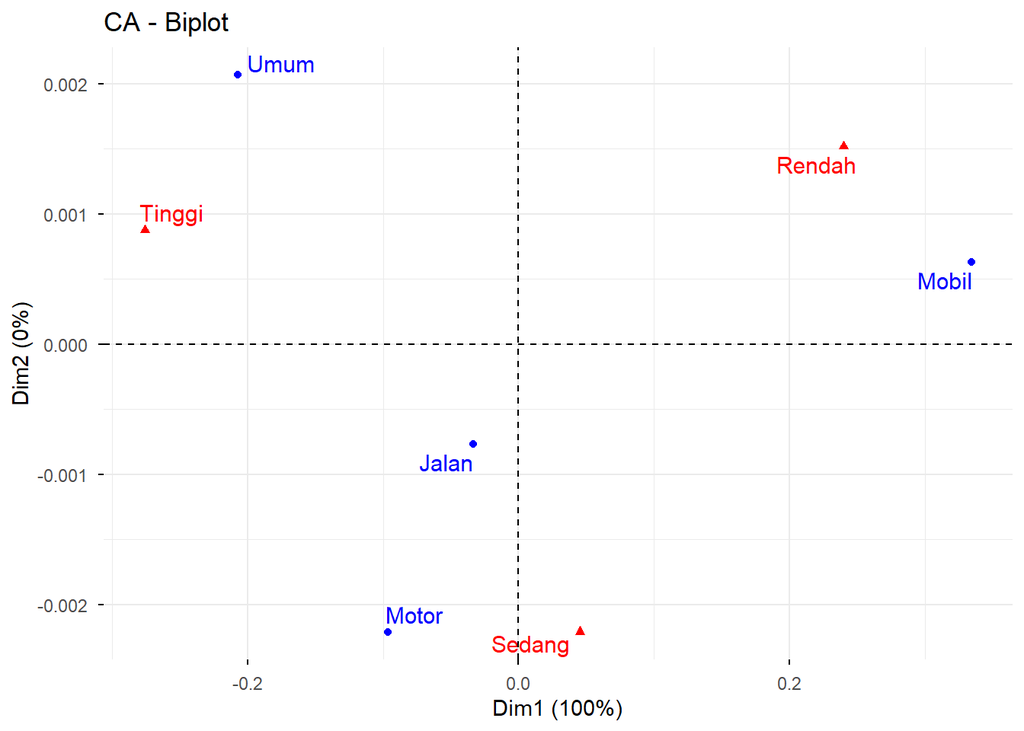

```r
fviz_ca_biplot(modelCA, repel = TRUE)
```

Biplot Analisis Korespondensi menunjukkan bahwa kategori Mobil berada relatif dekat dengan tingkat kepuasan Rendah, yang mengindikasikan kecenderungan pengguna mobil memiliki tingkat kepuasan yang lebih rendah dibanding kategori lainnya.

Sebaliknya, kategori Transportasi Umum (Umum) terletak dekat dengan kepuasan Tinggi, sehingga menunjukkan adanya kecenderungan asosiasi antara penggunaan transportasi umum dan tingkat kepuasan yang lebih tinggi.

Kategori Motor dan Jalan berada relatif dekat dengan pusat koordinat, yang mengindikasikan bahwa kedua jenis transportasi tersebut tidak memiliki asosiasi yang kuat dengan tingkat kepuasan tertentu.

Selain itu, karena hampir seluruh variasi data dijelaskan oleh Dimensi 1, interpretasi hubungan antar kategori terutama didasarkan pada posisi horizontal, sementara Dimensi 2 memiliki peran yang sangat kecil dalam menjelaskan pola data.

# Ringkasan

1. Kasus dan Data

Analisis dilakukan untuk mengkaji hubungan antara jenis transportasi dan tingkat kepuasan menggunakan data kategorik yang dibangkitkan di R

2. Kesesuaian Data

Data memenuhi syarat Analisis Korespondensi karena terdiri dari dua variabel kategorik, yaitu Transport dan Puas, yang disusun dalam bentuk tabel kontingensi.

3. Proses Analisis

Analisis dilakukan sesuai modul, meliputi pembuatan tabel kontingensi, uji Chi-Square, Analisis Korespondensi (CA), dan visualisasi biplot.

4. Hasil dan Interpretasi

Biplot menunjukkan Mobil cenderung berasosiasi dengan kepuasan Rendah dan transportasi umum dengan kepuasan Tinggi, sementara kategori lain tidak menunjukkan pola yang kuat.